# 5 Subgroup analysis

Workflow to establish a subgroup analysis after multiple imputation and propensity Score matching

Author

Janick Weberpals, RPh, PhD

Published

September 19, 2024

This is a reproducible example on how to establish a workflow to run a subgroup analysis after multiple imputation and propensity Score matching.

Load packages:

```r
library(dplyr)
library(survival)
library(mice)
library(MatchThem)
library(survey)
library(here)
library(gtsummary)
library(parallelly)
library(ranger)
library(furrr)

source(here("functions", "source_encore.io_functions.R"))

# track time
runtime <- tictoc::tic()
```

## 5.1 About

This script is adapted from Noah Greifer’s highly recommended blog post on “[Subgroup Analysis After Propensity Score Matching Using R](https://ngreifer.github.io/blog/subgroup-analysis-psm/)”.

For a more formal manuscript on subgroup analysis with propensity scores, see Green and Stuart.(Green and Stuart 2014)

## 5.2 Data generation

We again use the `simulate_flaura()` function to simulate a realistic oncology comparative effectiveness cohort analytic dataset.

```r
# load example dataset with missing observations
data_miss <- simulate_flaura(
  n_total = 3500,
  seed = 42,
  include_id = FALSE,
  imposeNA = TRUE,
  propNA = .13
  ) |>
  # we simplify and assume a binary Asian/non-Asian race covariate where Asian is the reference group
  mutate(dem_race = ifelse(dem_race == "Asian", 0, 1))
```

## 5.3 Moderator covariate

In this example, we assume heterogeneous treatment effect by race and we aim to assess the average treatment effect among the treated for Asian (reference) and non-Asian patients. The effect size is time to all-cause mortality. In this dataset, race is encoded with a binary covariate with 0 = Asian and 1 = non-Asian.

```r
table(data_miss$dem_race, useNA = "ifany")
```

```
   0    1 <NA>
1854 1166  480
```

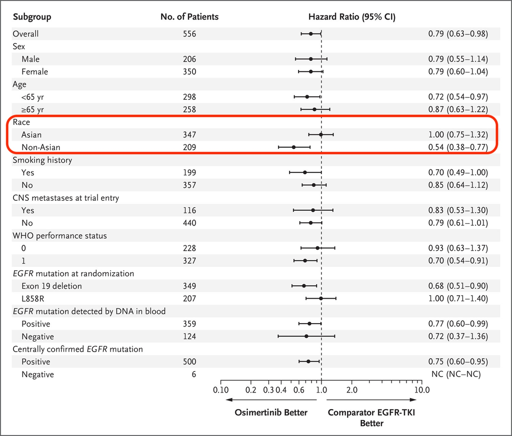

Investigated subgroup effect in the FLAURA trial.

## 5.4 Multiple imputation

```r
# impute data
data_imp <- futuremice(
  parallelseed = 42,
  n.core = parallel::detectCores()-1,
  data = data_miss,
  method = "rf",
  m = 10,
  print = FALSE
  )
```

## 5.5 Propensity score matching and weighting

```r
# apply propensity score matching on mids object
ps_form <- as.formula(paste("treat ~", paste(covariates_for_ps, collapse = " + ")))
ps_form
```

```
treat ~ dem_age_index_cont + dem_sex_cont + c_smoking_history +
    c_number_met_sites + c_hemoglobin_g_dl_cont + c_urea_nitrogen_mg_dl_cont +
    c_platelets_10_9_l_cont + c_calcium_mg_dl_cont + c_glucose_mg_dl_cont +
    c_lymphocyte_leukocyte_ratio_cont + c_alp_u_l_cont + c_protein_g_l_cont +
    c_alt_u_l_cont + c_albumin_g_l_cont + c_bilirubin_mg_dl_cont +
    c_chloride_mmol_l_cont + c_monocytes_10_9_l_cont + c_eosinophils_leukocytes_ratio_cont +
    c_ldh_u_l_cont + c_hr_cont + c_sbp_cont + c_oxygen_cont +
    c_ecog_cont + c_neutrophil_lymphocyte_ratio_cont + c_bmi_cont +
    c_ast_alt_ratio_cont + c_stage_initial_dx_cont + dem_race +
    dem_region + dem_ses + c_time_dx_to_index
```

**Matching**

```r
match_within_strata <- function(i,
                                imputed_data = NULL,
                                ps_formula = NULL,
                                filter_expr = NULL
                                ){

  stratum <- mice::complete(imputed_data, i) |>
    dplyr::filter(eval(filter_expr))

  matched <- MatchIt::matchit(
    formula = ps_formula,
    data = stratum,
    method = "nearest",
    caliper = 0.01,
    ratio = 1,
    replace = F
    ) |>
    MatchIt::match.data()

  return(matched)

}

asian_matched <- lapply(
  X = 1:data_imp$m,
  FUN = match_within_strata,
  imputed_data = data_imp,
  ps_formula = ps_form,
  filter_expr = expr(dem_race == 0)
  )

non_asian_matched <- lapply(
  X = 1:data_imp$m,
  FUN = match_within_strata,
  imputed_data = data_imp,
  ps_formula = ps_form,
  filter_expr = expr(dem_race == 1)
  )

# combine the mth imputed and matched datasets
combine_list <- function(i, data_0 = NULL, data_1 = NULL){

  data_combined <- rbind(data_0[[i]], data_1[[i]])

  return(data_combined)

}

matched_all <- lapply(
  X = 1:data_imp$m,
  FUN = combine_list,
  data_0 = non_asian_matched,
  data_1 = asian_matched
  )
```

**Weighting**

```r
weight_within_strata <- function(i,
                                 imputed_data = NULL,
                                 ps_formula = NULL,
                                 filter_expr = NULL
                                 ){

  stratum <- mice::complete(imputed_data, i) |>
    dplyr::filter(eval(filter_expr))

  weighted <- WeightIt::weightit(
    formula = ps_formula,
    data = stratum,
    method = "glm",
    estimand = "ATT"
    )

  # trim extreme weights
  weighted <- trim(
    x = weighted,
    at = .95,
    lower = TRUE
    )

  weighted_data <- mice::complete(imputed_data, i) |>
    dplyr::filter(eval(filter_expr)) |>
    mutate(weights = weighted$weights)

  return(weighted_data)

}

asian_weighted <- lapply(
  X = 1:data_imp$m,
  FUN = weight_within_strata,
  imputed_data = data_imp,
  ps_formula = ps_form,
  filter_expr = expr(dem_race == 0)
  )

non_asian_weighted <- lapply(
  X = 1:data_imp$m,
  FUN = weight_within_strata,
  imputed_data = data_imp,
  ps_formula = ps_form,
  filter_expr = expr(dem_race == 1)
  )

weighted_all <- lapply(
  X = 1:data_imp$m,
  FUN = combine_list,
  data_0 = asian_weighted,
  data_1 = non_asian_weighted
  )
```

## 5.6 Outcome model comparisons

**Matching**

```r
cox_fit_matching <- function(i){

  survival_fit <- survival::coxph(
    data = i,
    formula = Surv(fu_itt_months, death_itt) ~ treat*dem_race,
    weights = weights,
    cluster = subclass,
    robust = TRUE
    )

}
```

```r
matched_all |>
  lapply(FUN = cox_fit_matching) |>
  mice::pool() |>
  broom::tidy(exponentiate = TRUE, conf.int = TRUE) |>
  dplyr::select(term, estimate, std.error, conf.low, conf.high)
```

```
            term  estimate  std.error  conf.low conf.high
1          treat 1.0164611 0.06285385 0.8964279 1.1525669
2       dem_race 1.0168610 0.06594461 0.8929551 1.1579600
3 treat:dem_race 0.5838534 0.10944305 0.4687215 0.7272652
```

**Weighting**

```r
cox_fit_weighting <- function(i){

  survival_fit <- survival::coxph(
    data = i,
    formula = Surv(fu_itt_months, death_itt) ~ treat*dem_race,
    weights = weights,
    robust = TRUE
    )

}
```

```r
weighted_all |>
  lapply(FUN = cox_fit_weighting) |>
  mice::pool() |>
  broom::tidy(exponentiate = TRUE, conf.int = TRUE) |>
  dplyr::select(term, estimate, std.error, conf.low, conf.high)
```

```
            term  estimate  std.error  conf.low conf.high
1          treat 1.0129437 0.04540748 0.9265436  1.107401
2       dem_race 1.0140269 0.05675557 0.9070347  1.133640
3 treat:dem_race 0.5930234 0.07725232 0.5094262  0.690339
```

## 5.7 References

Green, Kerry M., and Elizabeth A. Stuart. 2014. “Examining Moderation Analyses in Propensity Score Methods: Application to Depression and Substance Use.” *Journal of Consulting and Clinical Psychology* 82 (5): 773–83. https://doi.org/10.1037/a0036515.

## 5.8 Session info

Script runtime: 0.66 minutes.

**Loaded packages**

```r
pander::pander(subset(data.frame(sessioninfo::package_info()), attached==TRUE, c(package, loadedversion)))
```

|  | package | loadedversion |
| --- | --- | --- |
| **dplyr** | dplyr | 1.1.4 |
| **furrr** | furrr | 0.3.1 |
| **future** | future | 1.34.0 |
| **gtsummary** | gtsummary | 2.0.1 |
| **here** | here | 1.0.1 |
| **MatchThem** | MatchThem | 1.2.1 |
| **Matrix** | Matrix | 1.7-0 |
| **mice** | mice | 3.16.0 |
| **parallelly** | parallelly | 1.38.0 |
| **ranger** | ranger | 0.16.0 |
| **survey** | survey | 4.4-2 |
| **survival** | survival | 3.5-8 |

**Session info**

**R version 4.4.0 (2024-04-24)**

**Platform:** aarch64-apple-darwin20

**locale:** en_US.UTF-8||en_US.UTF-8||en_US.UTF-8||C||en_US.UTF-8||en_US.UTF-8

**attached base packages:** *grid*, *stats*, *graphics*, *grDevices*, *datasets*, *utils*, *methods* and *base*

**other attached packages:** *furrr(v.0.3.1)*, *future(v.1.34.0)*, *ranger(v.0.16.0)*, *parallelly(v.1.38.0)*, *gtsummary(v.2.0.1)*, *here(v.1.0.1)*, *survey(v.4.4-2)*, *Matrix(v.1.7-0)*, *MatchThem(v.1.2.1)*, *mice(v.3.16.0)*, *survival(v.3.5-8)* and *dplyr(v.1.1.4)*

**loaded via a namespace (and not attached):** *gtable(v.0.3.5)*, *shape(v.1.4.6.1)*, *xfun(v.0.47)*, *ggplot2(v.3.5.1)*, *htmlwidgets(v.1.6.4)*, *MatchIt(v.4.5.5)*, *lattice(v.0.22-6)*, *simsurv(v.1.0.0)*, *vctrs(v.0.6.5)*, *tools(v.4.4.0)*, *generics(v.0.1.3)*, *parallel(v.4.4.0)*, *tibble(v.3.2.1)*, *fansi(v.1.0.6)*, *pan(v.1.9)*, *pkgconfig(v.2.0.3)*, *jomo(v.2.7-6)*, *assertthat(v.0.2.1)*, *lifecycle(v.1.0.4)*, *stringr(v.1.5.1)*, *compiler(v.4.4.0)*, *tictoc(v.1.2.1)*, *munsell(v.0.5.1)*, *mitools(v.2.4)*, *codetools(v.0.2-20)*, *htmltools(v.0.5.8.1)*, *yaml(v.2.3.10)*, *glmnet(v.4.1-8)*, *pillar(v.1.9.0)*, *nloptr(v.2.1.1)*, *crayon(v.1.5.3)*, *tidyr(v.1.3.1)*, *MASS(v.7.3-60.2)*, *sessioninfo(v.1.2.2)*, *iterators(v.1.0.14)*, *rpart(v.4.1.23)*, *boot(v.1.3-30)*, *foreach(v.1.5.2)*, *mitml(v.0.4-5)*, *nlme(v.3.1-164)*, *locfit(v.1.5-9.10)*, *WeightIt(v.1.3.0)*, *tidyselect(v.1.2.1)*, *digest(v.0.6.37)*, *stringi(v.1.8.4)*, *pander(v.0.6.5)*, *listenv(v.0.9.1)*, *purrr(v.1.0.2)*, *splines(v.4.4.0)*, *rprojroot(v.2.0.4)*, *fastmap(v.1.2.0)*, *colorspace(v.2.1-1)*, *cli(v.3.6.3)*, *magrittr(v.2.0.3)*, *utf8(v.1.2.4)*, *broom(v.1.0.6)*, *withr(v.3.0.1)*, *scales(v.1.3.0)*, *backports(v.1.5.0)*, *rmarkdown(v.2.28)*, *globals(v.0.16.3)*, *nnet(v.7.3-19)*, *lme4(v.1.1-35.5)*, *chk(v.0.9.2)*, *evaluate(v.0.24.0)*, *knitr(v.1.48)*, *rlang(v.1.1.4)*, *Rcpp(v.1.0.13)*, *glue(v.1.7.0)*, *DBI(v.1.2.3)*, *renv(v.1.0.7)*, *rstudioapi(v.0.16.0)*, *minqa(v.1.2.8)*, *jsonlite(v.1.8.8)* and *R6(v.2.5.1)*

**Repositories**

```r
pander::pander(options('repos'))
```

- **repos**:

  | REPO_NAME |
  | --- |
  | https://packagemanager.posit.co/cran/latest |